# Assignment 2

James Guy

2024-03-24

1. To reduce overfitting I used data augmentation with the below model.

```r
#Loading the appropriate libraries
library(reticulate)
library(tensorflow)
library(keras)
library(magrittr)
reticulate::py_install('pillow')
```

```
## Using virtual environment "C:/Users/reape/OneDrive/Documents/.virtualenvs/r-tensorflow" ...
```

```
## + "C:/Users/reape/OneDrive/Documents/.virtualenvs/r-tensorflow/Scripts/python.exe" -m pip install --upgrade --no-user pillow
```

```r
# Define paths
original_dataset_dir <- 'C:/Users/reape/OneDrive/Documents/Masters Program/Spring 2024/Advanced Machine Learning/Assignment 2/kagglecatsanddogs_5340/PetImages'
base_dir <- 'C:/Users/reape/OneDrive/Documents/Masters Program/Spring 2024/Advanced Machine Learning/Assignment 2/cats_vs_dogs_small_dataset/cats_vs_dogs_small_dataset'
```

```r
# Directories for the training, validation, and test splits
train_dir_1 <- file.path(base_dir, 'train')
dir.create(train_dir_1)
validation_dir_1 <- file.path(base_dir, 'validation')
dir.create(validation_dir_1)
test_dir_1 <- file.path(base_dir, 'test')
dir.create(test_dir_1)
```

```r
# Subdirectories for training, validation, and test splits for cats and dogs
train_cats_dir_1 <- file.path(train_dir_1, 'cats')
dir.create(train_cats_dir_1)
train_dogs_dir_1 <- file.path(train_dir_1, 'dogs')
dir.create(train_dogs_dir_1)

validation_cats_dir_1 <- file.path(validation_dir_1, 'cats')
dir.create(validation_cats_dir_1)
validation_dogs_dir_1 <- file.path(validation_dir_1, 'dogs')
dir.create(validation_dogs_dir_1)

test_cats_dir_1 <- file.path(test_dir_1, 'cats')
dir.create(test_cats_dir_1)
test_dogs_dir_1 <- file.path(test_dir_1, 'dogs')
dir.create(test_dogs_dir_1)
```

```r
# Directory paths
base_dir <- "C:/Users/reape/OneDrive/Documents/Masters Program/Spring 2024/Advanced Machine Learning/Assignment 2/cats_vs_dogs_small_dataset/cats_vs_dogs_small_dataset"

cats_source_dir <- file.path(base_dir, "cat")
dogs_source_dir <- file.path(base_dir, "dog")

# Define target directories
train_cats_dir_1 <- file.path(base_dir, 'train/cats')
validation_cats_dir_1 <- file.path(base_dir, 'validation/cats')
test_cats_dir_1 <- file.path(base_dir, 'test/cats')

train_dogs_dir_1 <- file.path(base_dir, 'train/dogs')
validation_dogs_dir_1 <- file.path(base_dir, 'validation/dogs')
test_dogs_dir_1 <- file.path(base_dir, 'test/dogs')
```

```r
# Function to copy images based on numeric naming convention
copy_images <- function(start_index, end_index, source_dir_base, target_dir) {
  for (i in start_index:end_index) {
    file_name <- sprintf("%d.jpg", i)
    file_path <- file.path(source_dir_base, file_name)
    if(file.exists(file_path)) { # Check if file exists before copying
      file.copy(file_path, target_dir)
    }
  }
}

# Base directory for source images
base_dir <- "C:/Users/reape/OneDrive/Documents/Masters Program/Spring 2024/Advanced Machine Learning/Assignment 2/cats_vs_dogs_small_dataset/cats_vs_dogs_small_dataset"

# Subdirectory for cats and dogs
cats_dir <- file.path(base_dir, "cat")
dogs_dir <- file.path(base_dir, "dog")

# Define target directories
train_cats_dir_1 <- file.path(base_dir, 'train/cats')
validation_cats_dir_1 <- file.path(base_dir, 'validation/cats')
test_cats_dir_1 <- file.path(base_dir, 'test/cats')

train_dogs_dir_1 <- file.path(base_dir, 'train/dogs')
validation_dogs_dir_1 <- file.path(base_dir, 'validation/dogs')
test_dogs_dir_1 <- file.path(base_dir, 'test/dogs')

# Use the function to copy the images

copy_images(0, 999, cats_dir, train_cats_dir_1)
copy_images(1000, 1499, cats_dir, validation_cats_dir_1)
copy_images(1500, 1999, cats_dir, test_cats_dir_1)


copy_images(0, 999, dogs_dir, train_dogs_dir_1)
copy_images(1000, 1499, dogs_dir, validation_dogs_dir_1)
copy_images(1500, 1999, dogs_dir, test_dogs_dir_1)
```

```r
#Building the model
library(keras)

model_1 <- keras_model_sequential() %>%
  layer_conv_2d(filters = 32, kernel_size = c(3, 3), activation = 'relu',
                input_shape = c(150, 150, 3)) %>%
  layer_max_pooling_2d(pool_size = c(2, 2)) %>%
  layer_conv_2d(filters = 64, kernel_size = c(3, 3), activation = 'relu') %>%
  layer_max_pooling_2d(pool_size = c(2, 2)) %>%
  layer_conv_2d(filters = 128, kernel_size = c(3, 3), activation = 'relu') %>%
  layer_max_pooling_2d(pool_size = c(2, 2)) %>%
  layer_conv_2d(filters = 128, kernel_size = c(3, 3), activation = 'relu') %>%
  layer_max_pooling_2d(pool_size = c(2, 2)) %>%
  layer_flatten() %>%
  layer_dense(units = 512, activation = 'relu') %>%
  layer_dense(units = 1, activation = 'sigmoid')
```

```r
summary(model_1)
```

```
## Model: "sequential"
## ________________________________________________________________________________
##  Layer (type)                       Output Shape                    Param #
## ================================================================================
##  conv2d_3 (Conv2D)                  (None, 148, 148, 32)            896
##  max_pooling2d_3 (MaxPooling2D)     (None, 74, 74, 32)              0
##  conv2d_2 (Conv2D)                  (None, 72, 72, 64)              18496
##  max_pooling2d_2 (MaxPooling2D)     (None, 36, 36, 64)              0
##  conv2d_1 (Conv2D)                  (None, 34, 34, 128)             73856
##  max_pooling2d_1 (MaxPooling2D)     (None, 17, 17, 128)             0
##  conv2d (Conv2D)                    (None, 15, 15, 128)             147584
##  max_pooling2d (MaxPooling2D)       (None, 7, 7, 128)               0
##  flatten (Flatten)                  (None, 6272)                    0
##  dense_1 (Dense)                    (None, 512)                     3211776
##  dense (Dense)                      (None, 1)                       513
## ================================================================================
## Total params: 3453121 (13.17 MB)
## Trainable params: 3453121 (13.17 MB)
## Non-trainable params: 0 (0.00 Byte)
## ________________________________________________________________________________
```

```r
model_1 %>% compile(
  loss = 'binary_crossentropy',
  optimizer = optimizer_rmsprop(learning_rate = 1e-4),
  metrics = c('accuracy')
)
```

```r
#Data Preprocessing and Augmentation
train_datagen_1 <- image_data_generator(
  rescale = 1/255,
  rotation_range = 40,
  width_shift_range = 0.2,
  height_shift_range = 0.2,
  shear_range = 0.2,
  zoom_range = 0.2,
  horizontal_flip = TRUE,
  fill_mode = 'nearest'
)

test_datagen_1 <- image_data_generator(rescale = 1/255)

train_generator_1 <- flow_images_from_directory(
  train_dir_1,
  train_datagen_1,
  target_size = c(150, 150),
  batch_size = 20,
  class_mode = 'binary'
)
```

```
## Found 2000 images belonging to 2 classes.
```

```r
validation_generator_1 <- flow_images_from_directory(
  validation_dir_1,
  test_datagen_1,
  target_size = c(150, 150),
  batch_size = 20,
  class_mode = 'binary'
)
```

```
## Found 1000 images belonging to 2 classes.
```

```r
# Use the generator_next function to retrieve the next batch
batch_1 <- generator_next(train_generator_1)


data_batch_1 <- batch_1[[1]]
labels_batch_1 <- batch_1[[2]]

# Print the dimensions of the data and labels batch
cat("Data batch shape:", dim(data_batch_1), "\n")
```

```
## Data batch shape: 20 150 150 3
```

```r
cat("Labels batch shape:", length(labels_batch_1), "\n")
```

```
## Labels batch shape: 20
```

```r
#Training the model with data augmentation

history_1 <- model_1 %>% fit(
  x = train_generator_1,
  steps_per_epoch = 100,
  epochs = 30,
  validation_data = validation_generator_1,
  validation_steps = 50
)
```

```
## 100/100 - 8s - loss: 0.6936 - accuracy: 0.5125 - val_loss: 0.6909 - val_accuracy: 0.5070 - 8s/epoch - 79ms/step
## 100/100 - 7s - loss: 0.6893 - accuracy: 0.5325 - val_loss: 0.6789 - val_accuracy: 0.6000 - 7s/epoch - 75ms/step
## 100/100 - 8s - loss: 0.6812 - accuracy: 0.5585 - val_loss: 0.6804 - val_accuracy: 0.5190 - 8s/epoch - 76ms/step
## 100/100 - 8s - loss: 0.6681 - accuracy: 0.5930 - val_loss: 0.6659 - val_accuracy: 0.5670 - 8s/epoch - 77ms/step
## 100/100 - 7s - loss: 0.6578 - accuracy: 0.5995 - val_loss: 0.6336 - val_accuracy: 0.6360 - 7s/epoch - 74ms/step
## 100/100 - 7s - loss: 0.6394 - accuracy: 0.6325 - val_loss: 0.6277 - val_accuracy: 0.6410 - 7s/epoch - 74ms/step
## 100/100 - 7s - loss: 0.6328 - accuracy: 0.6365 - val_loss: 0.6053 - val_accuracy: 0.6700 - 7s/epoch - 73ms/step
## 100/100 - 7s - loss: 0.6263 - accuracy: 0.6445 - val_loss: 0.6023 - val_accuracy: 0.6700 - 7s/epoch - 75ms/step
## 100/100 - 8s - loss: 0.6128 - accuracy: 0.6665 - val_loss: 0.6328 - val_accuracy: 0.6280 - 8s/epoch - 81ms/step
## 100/100 - 8s - loss: 0.6113 - accuracy: 0.6645 - val_loss: 0.5901 - val_accuracy: 0.6770 - 8s/epoch - 75ms/step
## 100/100 - 7s - loss: 0.5995 - accuracy: 0.6840 - val_loss: 0.6223 - val_accuracy: 0.6350 - 7s/epoch - 74ms/step
## 100/100 - 7s - loss: 0.5800 - accuracy: 0.6975 - val_loss: 0.5941 - val_accuracy: 0.6660 - 7s/epoch - 74ms/step
## 100/100 - 7s - loss: 0.5824 - accuracy: 0.6950 - val_loss: 0.5704 - val_accuracy: 0.7030 - 7s/epoch - 73ms/step
## 100/100 - 7s - loss: 0.5792 - accuracy: 0.6945 - val_loss: 0.5683 - val_accuracy: 0.6850 - 7s/epoch - 75ms/step
## 100/100 - 7s - loss: 0.5797 - accuracy: 0.6875 - val_loss: 0.5586 - val_accuracy: 0.6960 - 7s/epoch - 75ms/step
## 100/100 - 8s - loss: 0.5781 - accuracy: 0.7020 - val_loss: 0.5526 - val_accuracy: 0.7030 - 8s/epoch - 75ms/step
## 100/100 - 8s - loss: 0.5657 - accuracy: 0.7045 - val_loss: 0.5612 - val_accuracy: 0.6990 - 8s/epoch - 76ms/step
## 100/100 - 7s - loss: 0.5660 - accuracy: 0.7025 - val_loss: 0.5411 - val_accuracy: 0.7080 - 7s/epoch - 75ms/step
## 100/100 - 7s - loss: 0.5678 - accuracy: 0.7035 - val_loss: 0.5432 - val_accuracy: 0.7050 - 7s/epoch - 73ms/step
## 100/100 - 7s - loss: 0.5564 - accuracy: 0.7055 - val_loss: 0.5325 - val_accuracy: 0.7120 - 7s/epoch - 73ms/step
## 100/100 - 7s - loss: 0.5541 - accuracy: 0.7140 - val_loss: 0.5561 - val_accuracy: 0.7040 - 7s/epoch - 73ms/step
## 100/100 - 8s - loss: 0.5457 - accuracy: 0.7265 - val_loss: 0.5371 - val_accuracy: 0.7140 - 8s/epoch - 75ms/step
## 100/100 - 7s - loss: 0.5529 - accuracy: 0.7215 - val_loss: 0.5738 - val_accuracy: 0.6960 - 7s/epoch - 73ms/step
## 100/100 - 7s - loss: 0.5376 - accuracy: 0.7310 - val_loss: 0.5652 - val_accuracy: 0.7100 - 7s/epoch - 73ms/step
## 100/100 - 7s - loss: 0.5256 - accuracy: 0.7325 - val_loss: 0.5300 - val_accuracy: 0.7240 - 7s/epoch - 73ms/step
## 100/100 - 7s - loss: 0.5337 - accuracy: 0.7270 - val_loss: 0.5428 - val_accuracy: 0.7180 - 7s/epoch - 73ms/step
## 100/100 - 8s - loss: 0.5375 - accuracy: 0.7225 - val_loss: 0.5090 - val_accuracy: 0.7440 - 8s/epoch - 75ms/step
## 100/100 - 8s - loss: 0.5342 - accuracy: 0.7285 - val_loss: 0.5235 - val_accuracy: 0.7250 - 8s/epoch - 78ms/step
## 100/100 - 8s - loss: 0.5245 - accuracy: 0.7410 - val_loss: 0.4980 - val_accuracy: 0.7510 - 8s/epoch - 77ms/step
## 100/100 - 8s - loss: 0.5219 - accuracy: 0.7300 - val_loss: 0.5273 - val_accuracy: 0.7290 - 8s/epoch - 77ms/step
```

```r
#Saving the model
save_model_tf(model_1, "model_1")
```

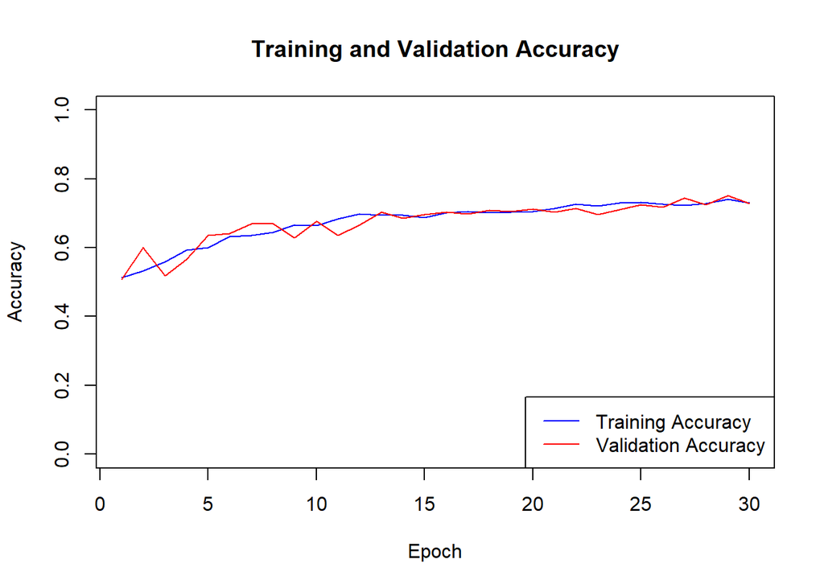

```r
# Plotting Training & Validation Accuracy
plot(history_1$metrics$acc, type = 'l', col = 'blue', ylim = c(0, 1), ylab = 'Accuracy', xlab = 'Epoch', main = 'Training and Validation Accuracy')
lines(history_1$metrics$val_acc, type = 'l', col = 'red')
legend('bottomright', legend = c('Training Accuracy', 'Validation Accuracy'), col = c('blue', 'red'), lty = 1)
```

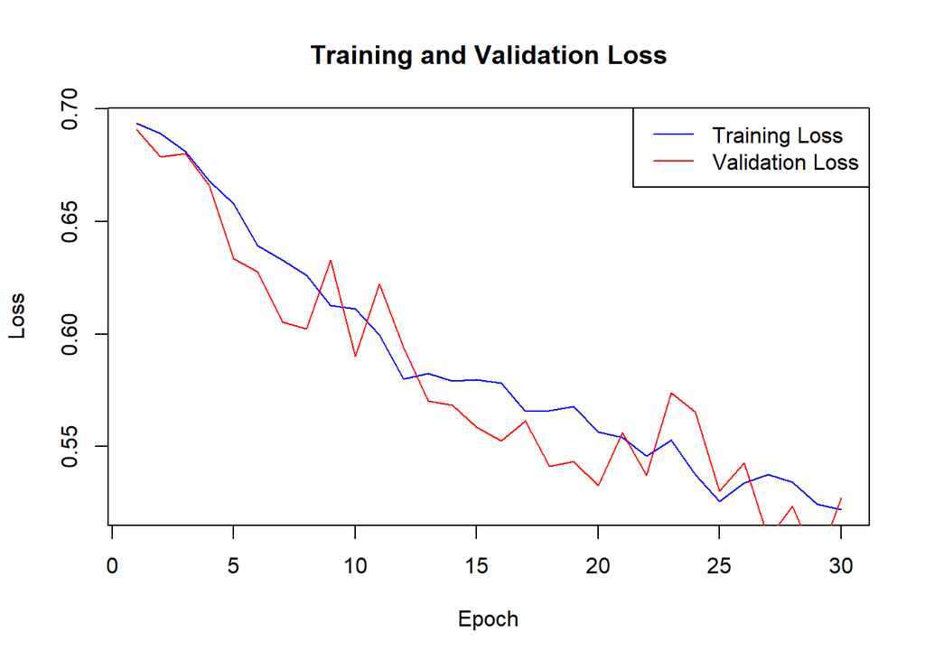

```r
# Plotting Training & Validation Loss
plot(history_1$metrics$loss, type = 'l', col = 'blue', ylab = 'Loss', xlab = 'Epoch', main = 'Training and Validation Loss')
lines(history_1$metrics$val_loss, type = 'l', col = 'red')
legend('topright', legend = c('Training Loss', 'Validation Loss'), col = c('blue', 'red'), lty = 1)
```

2. Increasing the training sample size by 500, training from scratch, and optimizing using regularization with data augmentation:

```r
# Define paths
original_dataset_dir <- 'C:/Users/reape/OneDrive/Documents/Masters Program/Spring 2024/Advanced Machine Learning/Assignment 2/kagglecatsanddogs_5340/PetImages'

# Directories
train_dir_2 <- file.path(original_dataset_dir, 'train_2')
dir.create(train_dir_2)
validation_dir_2 <- file.path(original_dataset_dir, 'validation_2')
dir.create(validation_dir_2)
test_dir_2 <- file.path(original_dataset_dir, 'test_2')
dir.create(test_dir_2)

# Subdirectories for training, validation, and test splits for cats and dogs
train_cats_dir_2 <- file.path(train_dir_2, 'cats')
dir.create(train_cats_dir_2)
train_dogs_dir_2 <- file.path(train_dir_2, 'dogs')
dir.create(train_dogs_dir_2)

validation_cats_dir_2 <- file.path(validation_dir_2, 'cats')
dir.create(validation_cats_dir_2)
validation_dogs_dir_2 <- file.path(validation_dir_2, 'dogs')
dir.create(validation_dogs_dir_2)

test_cats_dir_2 <- file.path(test_dir_2, 'cats')
dir.create(test_cats_dir_2)
test_dogs_dir_2 <- file.path(test_dir_2, 'dogs')
dir.create(test_dogs_dir_2)
```

```r
# Define the source directories for cats and dogs
cats_source_dir <- file.path(original_dataset_dir, "Cat")
dogs_source_dir <- file.path(original_dataset_dir, "Dog")

# Define target directories
train_cats_dir_2 <- file.path(train_dir_2, 'cats')
validation_cats_dir_2 <- file.path(validation_dir_2, 'cats')
test_cats_dir_2 <- file.path(test_dir_2, 'cats')

train_dogs_dir_2 <- file.path(train_dir_2, 'dogs')
validation_dogs_dir_2 <- file.path(validation_dir_2, 'dogs')
test_dogs_dir_2 <- file.path(test_dir_2, 'dogs')
```

```r
# Function to copy images based on numeric naming convention
copy_images <- function(start_index, end_index, source_dir_base, target_dir) {
  for (i in start_index:end_index) {
    file_name <- sprintf("%d.jpg", i)
    file_path <- file.path(source_dir_base, file_name)
    if(file.exists(file_path)) {
      file.copy(file_path, target_dir)
    }
  }
}

# Original base directory
original_dataset_dir <- 'C:/Users/reape/OneDrive/Documents/Masters Program/Spring 2024/Advanced Machine Learning/Assignment 2/kagglecatsanddogs_5340/PetImages'


original_cats_dir <- file.path(original_dataset_dir, "Cat")
original_dogs_dir <- file.path(original_dataset_dir, "Dog")

# Define target directories for model 2
train_cats_dir_2 <- file.path(train_dir_2, 'cats')
validation_cats_dir_2 <- file.path(validation_dir_2, 'cats')
test_cats_dir_2 <- file.path(test_dir_2, 'cats')

train_dogs_dir_2 <- file.path(train_dir_2, 'dogs')
validation_dogs_dir_2 <- file.path(validation_dir_2, 'dogs')
test_dogs_dir_2 <- file.path(test_dir_2, 'dogs')

# Use the function to copy the images with the updated source directories
# Increase training sample size to 1500 for model 2
copy_images(0, 1500, original_cats_dir, train_cats_dir_2)
copy_images(1501, 2000, original_cats_dir, validation_cats_dir_2)
copy_images(2001, 2500, original_cats_dir, test_cats_dir_2)

copy_images(0, 1500, original_dogs_dir, train_dogs_dir_2)
copy_images(1501, 2000, original_dogs_dir, validation_dogs_dir_2)
copy_images(2001, 2500, original_dogs_dir, test_dogs_dir_2)
```

```r
#Building the model and adding dropout

model_2 <- keras_model_sequential() %>%
  # Convolutional layers
  layer_conv_2d(filters = 32, kernel_size = c(3, 3), activation = 'relu', input_shape = c(150, 150, 3)) %>%
  layer_max_pooling_2d(pool_size = c(2, 2)) %>%
  layer_conv_2d(filters = 64, kernel_size = c(3, 3), activation = 'relu') %>%
  layer_max_pooling_2d(pool_size = c(2, 2)) %>%
  layer_conv_2d(filters = 128, kernel_size = c(3, 3), activation = 'relu') %>%
  layer_max_pooling_2d(pool_size = c(2, 2)) %>%
  layer_conv_2d(filters = 128, kernel_size = c(3, 3), activation = 'relu') %>%
  layer_max_pooling_2d(pool_size = c(2, 2)) %>%

  # Flattening the convolutional layer output to feed it into dense layers
  layer_flatten() %>%

  # First dense layer with L2 regularization
  layer_dense(units = 512, activation = 'relu', kernel_regularizer = regularizer_l2(0.001)) %>%

  # Dropout layer to reduce overfitting by randomly setting a fraction of input units to 0
  layer_dropout(rate = 0.5) %>%

  # Output layer with a single unit for binary classification
  layer_dense(units = 1, activation = 'sigmoid')

model_2 %>% compile(
  loss = 'binary_crossentropy',
  optimizer = optimizer_rmsprop(lr = 1e-4),
  metrics = c('accuracy')
)
```

```r
#Data Preprocessing and Augmentation
train_datagen_2 <- image_data_generator(
  rescale = 1/255,
  rotation_range = 40,
  width_shift_range = 0.2,
  height_shift_range = 0.2,
  shear_range = 0.2,
  zoom_range = 0.2,
  horizontal_flip = TRUE,
  fill_mode = 'nearest'
)

test_datagen_2 <- image_data_generator(rescale = 1/255)

train_generator_2 <- flow_images_from_directory(
  train_dir_2,
  train_datagen_2,
  target_size = c(150, 150),
  batch_size = 20,
  class_mode = 'binary'
)
```

```
## Found 3000 images belonging to 2 classes.
```

```r
validation_generator_2 <- flow_images_from_directory(
  validation_dir_2,
  test_datagen_2,
  target_size = c(150, 150),
  batch_size = 20,
  class_mode = 'binary'
)
```

```
## Found 1000 images belonging to 2 classes.
```

```r
# Use the generator_next function to retrieve the next batch
batch_2 <- generator_next(train_generator_2)


data_batch_2 <- batch_2[[1]]
labels_batch_2 <- batch_2[[2]]

# Print the dimensions of the data and labels batch
cat("Data batch shape:", dim(data_batch_2), "\n")
```

```
## Data batch shape: 20 150 150 3
```

```r
cat("Labels batch shape:", length(labels_batch_2), "\n")
```

```
## Labels batch shape: 20
```

```r
#Training the model with data augmentation

history_2 <- model_2 %>% fit(
  x = train_generator_2,
  steps_per_epoch = 150,
  epochs = 50, # Increased from 30 to 50
  validation_data = validation_generator_2,
  validation_steps = 50 #
)
```

```
## 150/150 - 11s - loss: 1.1413 - accuracy: 0.5277 - val_loss: 0.8389 - val_accuracy: 0.5340 - 11s/epoch - 75ms/step
## 150/150 - 11s - loss: 0.7584 - accuracy: 0.5597 - val_loss: 0.6940 - val_accuracy: 0.5750 - 11s/epoch - 72ms/step
## 150/150 - 11s - loss: 0.6851 - accuracy: 0.6017 - val_loss: 0.7096 - val_accuracy: 0.5670 - 11s/epoch - 72ms/step
## 150/150 - 11s - loss: 0.6619 - accuracy: 0.6213 - val_loss: 0.6646 - val_accuracy: 0.5960 - 11s/epoch - 72ms/step
## 150/150 - 11s - loss: 0.6468 - accuracy: 0.6443 - val_loss: 0.6235 - val_accuracy: 0.6670 - 11s/epoch - 72ms/step
## 150/150 - 11s - loss: 0.6373 - accuracy: 0.6613 - val_loss: 0.6206 - val_accuracy: 0.6760 - 11s/epoch - 72ms/step
## 150/150 - 11s - loss: 0.6337 - accuracy: 0.6623 - val_loss: 0.6170 - val_accuracy: 0.6680 - 11s/epoch - 71ms/step
## 150/150 - 11s - loss: 0.6202 - accuracy: 0.6727 - val_loss: 0.6415 - val_accuracy: 0.6720 - 11s/epoch - 72ms/step
## 150/150 - 11s - loss: 0.6187 - accuracy: 0.6720 - val_loss: 0.6456 - val_accuracy: 0.6360 - 11s/epoch - 72ms/step
## 150/150 - 11s - loss: 0.6236 - accuracy: 0.6730 - val_loss: 0.6239 - val_accuracy: 0.6450 - 11s/epoch - 72ms/step
## 150/150 - 11s - loss: 0.6121 - accuracy: 0.6917 - val_loss: 0.6227 - val_accuracy: 0.6800 - 11s/epoch - 71ms/step
## 150/150 - 11s - loss: 0.6096 - accuracy: 0.6807 - val_loss: 0.6146 - val_accuracy: 0.6770 - 11s/epoch - 71ms/step
## 150/150 - 11s - loss: 0.5846 - accuracy: 0.7123 - val_loss: 0.6193 - val_accuracy: 0.7160 - 11s/epoch - 71ms/step
## 150/150 - 11s - loss: 0.5919 - accuracy: 0.7007 - val_loss: 0.7031 - val_accuracy: 0.6540 - 11s/epoch - 71ms/step
## 150/150 - 11s - loss: 0.5940 - accuracy: 0.7033 - val_loss: 0.5862 - val_accuracy: 0.7060 - 11s/epoch - 71ms/step
## 150/150 - 11s - loss: 0.5779 - accuracy: 0.7203 - val_loss: 0.5765 - val_accuracy: 0.7390 - 11s/epoch - 71ms/step
## 150/150 - 11s - loss: 0.5952 - accuracy: 0.7093 - val_loss: 0.5815 - val_accuracy: 0.7290 - 11s/epoch - 71ms/step
## 150/150 - 11s - loss: 0.5799 - accuracy: 0.7250 - val_loss: 0.5957 - val_accuracy: 0.7050 - 11s/epoch - 71ms/step
## 150/150 - 11s - loss: 0.5808 - accuracy: 0.7210 - val_loss: 0.5459 - val_accuracy: 0.7460 - 11s/epoch - 71ms/step
## 150/150 - 11s - loss: 0.5646 - accuracy: 0.7320 - val_loss: 0.5483 - val_accuracy: 0.7490 - 11s/epoch - 72ms/step
## 150/150 - 11s - loss: 0.5671 - accuracy: 0.7350 - val_loss: 0.5712 - val_accuracy: 0.7350 - 11s/epoch - 72ms/step
## 150/150 - 11s - loss: 0.5612 - accuracy: 0.7263 - val_loss: 0.5462 - val_accuracy: 0.7600 - 11s/epoch - 72ms/step
## 150/150 - 11s - loss: 0.5534 - accuracy: 0.7427 - val_loss: 0.5531 - val_accuracy: 0.7560 - 11s/epoch - 72ms/step
## 150/150 - 11s - loss: 0.5481 - accuracy: 0.7423 - val_loss: 0.5934 - val_accuracy: 0.7380 - 11s/epoch - 72ms/step
## 150/150 - 11s - loss: 0.5558 - accuracy: 0.7483 - val_loss: 0.5398 - val_accuracy: 0.7680 - 11s/epoch - 73ms/step
## 150/150 - 11s - loss: 0.5499 - accuracy: 0.7360 - val_loss: 0.5343 - val_accuracy: 0.7690 - 11s/epoch - 73ms/step
## 150/150 - 11s - loss: 0.5459 - accuracy: 0.7420 - val_loss: 0.6714 - val_accuracy: 0.7100 - 11s/epoch - 71ms/step
## 150/150 - 11s - loss: 0.5382 - accuracy: 0.7560 - val_loss: 0.5498 - val_accuracy: 0.7470 - 11s/epoch - 72ms/step
## 150/150 - 11s - loss: 0.5236 - accuracy: 0.7573 - val_loss: 0.5973 - val_accuracy: 0.7500 - 11s/epoch - 71ms/step
## 150/150 - 11s - loss: 0.5442 - accuracy: 0.7473 - val_loss: 0.5247 - val_accuracy: 0.7570 - 11s/epoch - 71ms/step
## 150/150 - 11s - loss: 0.5388 - accuracy: 0.7620 - val_loss: 0.6282 - val_accuracy: 0.7420 - 11s/epoch - 71ms/step
## 150/150 - 11s - loss: 0.5270 - accuracy: 0.7583 - val_loss: 0.5430 - val_accuracy: 0.7700 - 11s/epoch - 71ms/step
## 150/150 - 11s - loss: 0.5310 - accuracy: 0.7600 - val_loss: 0.5904 - val_accuracy: 0.7620 - 11s/epoch - 72ms/step
## 150/150 - 11s - loss: 0.5210 - accuracy: 0.7570 - val_loss: 0.5326 - val_accuracy: 0.7840 - 11s/epoch - 71ms/step
## 150/150 - 11s - loss: 0.5103 - accuracy: 0.7717 - val_loss: 0.5217 - val_accuracy: 0.7840 - 11s/epoch - 72ms/step
## 150/150 - 11s - loss: 0.5153 - accuracy: 0.7670 - val_loss: 0.5177 - val_accuracy: 0.7740 - 11s/epoch - 71ms/step
## 150/150 - 11s - loss: 0.5100 - accuracy: 0.7817 - val_loss: 0.4929 - val_accuracy: 0.7980 - 11s/epoch - 73ms/step
## 150/150 - 11s - loss: 0.5119 - accuracy: 0.7680 - val_loss: 0.5191 - val_accuracy: 0.7910 - 11s/epoch - 72ms/step
## 150/150 - 11s - loss: 0.4950 - accuracy: 0.7867 - val_loss: 0.4876 - val_accuracy: 0.7960 - 11s/epoch - 71ms/step
## 150/150 - 11s - loss: 0.4870 - accuracy: 0.7893 - val_loss: 0.4953 - val_accuracy: 0.7970 - 11s/epoch - 72ms/step
## 150/150 - 11s - loss: 0.5014 - accuracy: 0.7740 - val_loss: 0.5166 - val_accuracy: 0.7820 - 11s/epoch - 71ms/step
## 150/150 - 11s - loss: 0.5011 - accuracy: 0.7830 - val_loss: 0.4656 - val_accuracy: 0.8050 - 11s/epoch - 70ms/step
## 150/150 - 11s - loss: 0.4842 - accuracy: 0.7937 - val_loss: 0.4710 - val_accuracy: 0.7980 - 11s/epoch - 71ms/step
## 150/150 - 11s - loss: 0.4835 - accuracy: 0.7877 - val_loss: 0.4984 - val_accuracy: 0.7970 - 11s/epoch - 71ms/step
## 150/150 - 11s - loss: 0.4781 - accuracy: 0.7877 - val_loss: 0.4849 - val_accuracy: 0.8040 - 11s/epoch - 71ms/step
## 150/150 - 11s - loss: 0.4794 - accuracy: 0.7997 - val_loss: 0.4660 - val_accuracy: 0.8110 - 11s/epoch - 71ms/step
## 150/150 - 11s - loss: 0.4820 - accuracy: 0.7957 - val_loss: 0.4426 - val_accuracy: 0.8150 - 11s/epoch - 71ms/step
## 150/150 - 11s - loss: 0.4694 - accuracy: 0.8030 - val_loss: 0.4350 - val_accuracy: 0.8260 - 11s/epoch - 72ms/step
## 150/150 - 11s - loss: 0.4749 - accuracy: 0.7940 - val_loss: 0.4800 - val_accuracy: 0.8040 - 11s/epoch - 72ms/step
## 150/150 - 11s - loss: 0.4687 - accuracy: 0.7997 - val_loss: 0.6493 - val_accuracy: 0.7690 - 11s/epoch - 72ms/step
```

```r
#Saving the model
save_model_tf(model_2, "model_2")
```

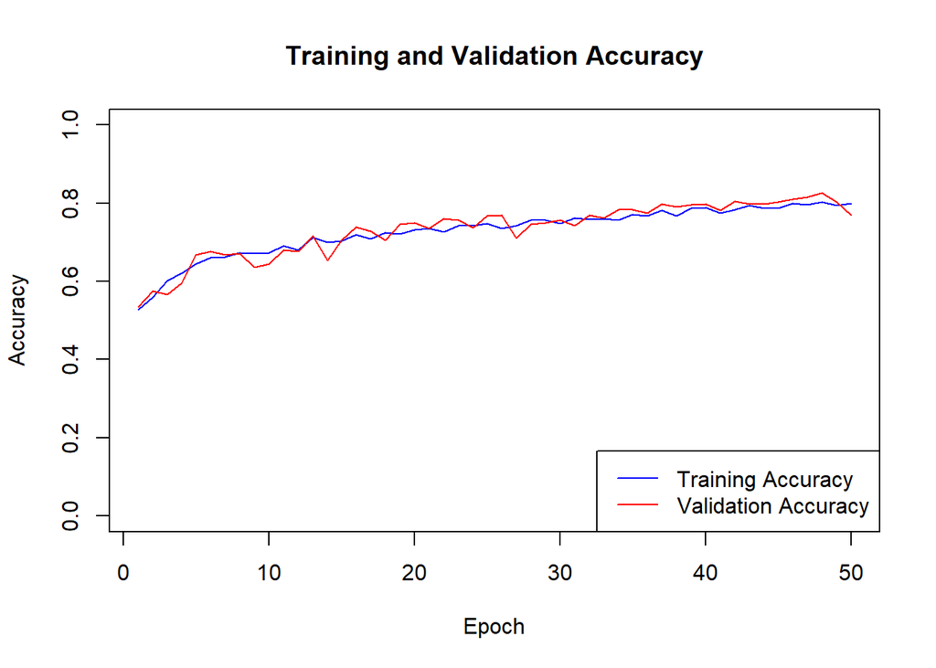

```r
# Plotting Training & Validation Accuracy
plot(history_2$metrics$acc, type = 'l', col = 'blue', ylim = c(0, 1), ylab = 'Accuracy', xlab = 'Epoch', main = 'Training and Validation Accuracy')
lines(history_2$metrics$val_acc, type = 'l', col = 'red')
legend('bottomright', legend = c('Training Accuracy', 'Validation Accuracy'), col = c('blue', 'red'), lty = 1)
```

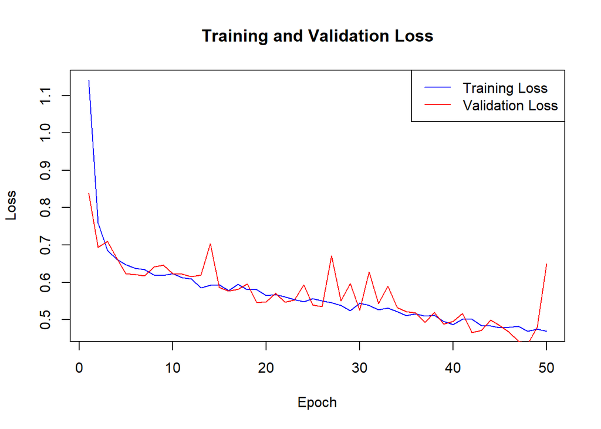

```r
# Plotting Training & Validation Loss
plot(history_2$metrics$loss, type = 'l', col = 'blue', ylab = 'Loss', xlab = 'Epoch', main = 'Training and Validation Loss')
lines(history_2$metrics$val_loss, type = 'l', col = 'red')
legend('topright', legend = c('Training Loss', 'Validation Loss'), col = c('blue', 'red'), lty = 1)
```

From the graphs we can see that using data augmentation with dropout provided an accuracy of about 80% and a loss of 50% at 50 epochs.

3. Increasing the training sample size by 1000, training from scratch, and optimizing using regularization with data augmentation:

```r
# Define paths
original_dataset_dir <- 'C:/Users/reape/OneDrive/Documents/Masters Program/Spring 2024/Advanced Machine Learning/Assignment 2/kagglecatsanddogs_5340/PetImages'

# Directories for training, validation, and test splits
train_dir_3 <- file.path(original_dataset_dir, 'train_3')
dir.create(train_dir_3)
validation_dir_3 <- file.path(original_dataset_dir, 'validation_3')
dir.create(validation_dir_3)
test_dir_3 <- file.path(original_dataset_dir, 'test_3')
dir.create(test_dir_3)

# Subdirectories for training, validation, and test splits for cats and dogs
train_cats_dir_3 <- file.path(train_dir_3, 'cats')
dir.create(train_cats_dir_3)
train_dogs_dir_3 <- file.path(train_dir_3, 'dogs')
dir.create(train_dogs_dir_3)

validation_cats_dir_3 <- file.path(validation_dir_3, 'cats')
dir.create(validation_cats_dir_3)
validation_dogs_dir_3 <- file.path(validation_dir_3, 'dogs')
dir.create(validation_dogs_dir_3)

test_cats_dir_3 <- file.path(test_dir_3, 'cats')
dir.create(test_cats_dir_3)
test_dogs_dir_3 <- file.path(test_dir_3, 'dogs')
dir.create(test_dogs_dir_3)
```

```r
# Define the source directories for cats and dogs
cats_source_dir <- file.path(original_dataset_dir, "Cat")
dogs_source_dir <- file.path(original_dataset_dir, "Dog")


train_cats_dir_3 <- file.path(train_dir_3, 'cats')
validation_cats_dir_3 <- file.path(validation_dir_3, 'cats')
test_cats_dir_3 <- file.path(test_dir_3, 'cats')

train_dogs_dir_3 <- file.path(train_dir_3, 'dogs')
validation_dogs_dir_3 <- file.path(validation_dir_3, 'dogs')
test_dogs_dir_3 <- file.path(test_dir_3, 'dogs')
```

```r
# Increasing the training sample to 4000
copy_images(0, 2000, file.path(original_dataset_dir, "Cat"), train_cats_dir_3)
copy_images(2001, 2500, file.path(original_dataset_dir, "Cat"), validation_cats_dir_3)
copy_images(2501, 3000, file.path(original_dataset_dir, "Cat"), test_cats_dir_3)

copy_images(0, 2000, file.path(original_dataset_dir, "Dog"), train_dogs_dir_3)
copy_images(2001, 2500, file.path(original_dataset_dir, "Dog"), validation_dogs_dir_3)
copy_images(2501, 3000, file.path(original_dataset_dir, "Dog"), test_dogs_dir_3)
```

```r
#Building the model

model_3 <- keras_model_sequential() %>%
  # Convolutional layers
  layer_conv_2d(filters = 32, kernel_size = c(3, 3), activation = 'relu', input_shape = c(150, 150, 3)) %>%
  layer_max_pooling_2d(pool_size = c(2, 2)) %>%
  layer_conv_2d(filters = 64, kernel_size = c(3, 3), activation = 'relu') %>%
  layer_max_pooling_2d(pool_size = c(2, 2)) %>%
  layer_conv_2d(filters = 128, kernel_size = c(3, 3), activation = 'relu') %>%
  layer_max_pooling_2d(pool_size = c(2, 2)) %>%
  layer_conv_2d(filters = 128, kernel_size = c(3, 3), activation = 'relu') %>%
  layer_max_pooling_2d(pool_size = c(2, 2)) %>%

  # Flattening the convolutional layer output to feed it into dense layers
  layer_flatten() %>%

  # First dense layer with L2 regularization
  layer_dense(units = 512, activation = 'relu', kernel_regularizer = regularizer_l2(0.001)) %>%

  # Dropout layer to reduce overfitting by randomly setting a fraction of input units to 0
  layer_dropout(rate = 0.5) %>%

  # Output layer with a single unit for binary classification
  layer_dense(units = 1, activation = 'sigmoid')

model_3 %>% compile(
  loss = 'binary_crossentropy',
  optimizer = optimizer_rmsprop(lr = 1e-4),
  metrics = c('accuracy')
)
```

```r
#Data Preprocessing and Augmentation
train_datagen_3 <- image_data_generator(
  rescale = 1/255,
  rotation_range = 40,
  width_shift_range = 0.2,
  height_shift_range = 0.2,
  shear_range = 0.2,
  zoom_range = 0.2,
  horizontal_flip = TRUE,
  fill_mode = 'nearest'
)

test_datagen_3 <- image_data_generator(rescale = 1/255)

train_generator_3 <- flow_images_from_directory(
  train_dir_3,
  train_datagen_3,
  target_size = c(150, 150),
  batch_size = 20,
  class_mode = 'binary'
)
```

```
## Found 4000 images belonging to 2 classes.
```

```r
validation_generator_3 <- flow_images_from_directory(
  validation_dir_3,
  test_datagen_3,
  target_size = c(150, 150),
  batch_size = 20,
  class_mode = 'binary'
)
```

```
## Found 1000 images belonging to 2 classes.
```

```r
# Use the generator_next function to retrieve the next batch
batch_3 <- generator_next(train_generator_3)


data_batch_3 <- batch_3[[1]]
labels_batch_3 <- batch_3[[2]]

# Print the dimensions of the data and labels batch
cat("Data batch shape:", dim(data_batch_3), "\n")
```

```
## Data batch shape: 20 150 150 3
```

```r
cat("Labels batch shape:", length(labels_batch_3), "\n")
```

```
## Labels batch shape: 20
```

```r
#Training the model

history_3 <- model_3 %>% fit(
  x = train_generator_3,
  steps_per_epoch = 200,
  epochs = 50,
  validation_data = validation_generator_3,
  validation_steps = 50
)
```

```
## 200/200 - 15s - loss: 1.0466 - accuracy: 0.5400 - val_loss: 0.7270 - val_accuracy: 0.6380 - 15s/epoch - 74ms/step
## 200/200 - 15s - loss: 0.7005 - accuracy: 0.5893 - val_loss: 0.6603 - val_accuracy: 0.6380 - 15s/epoch - 73ms/step
## 200/200 - 14s - loss: 0.6671 - accuracy: 0.6227 - val_loss: 0.6048 - val_accuracy: 0.6680 - 14s/epoch - 71ms/step
## 200/200 - 14s - loss: 0.6523 - accuracy: 0.6355 - val_loss: 0.5914 - val_accuracy: 0.7090 - 14s/epoch - 71ms/step
## 200/200 - 14s - loss: 0.6395 - accuracy: 0.6600 - val_loss: 0.5715 - val_accuracy: 0.7050 - 14s/epoch - 71ms/step
## 200/200 - 14s - loss: 0.6309 - accuracy: 0.6660 - val_loss: 0.5908 - val_accuracy: 0.6700 - 14s/epoch - 71ms/step
## 200/200 - 14s - loss: 0.6267 - accuracy: 0.6758 - val_loss: 0.5518 - val_accuracy: 0.7360 - 14s/epoch - 71ms/step
## 200/200 - 14s - loss: 0.6063 - accuracy: 0.6835 - val_loss: 0.5498 - val_accuracy: 0.7330 - 14s/epoch - 70ms/step
## 200/200 - 14s - loss: 0.6115 - accuracy: 0.6942 - val_loss: 0.5449 - val_accuracy: 0.7500 - 14s/epoch - 70ms/step
## 200/200 - 14s - loss: 0.6001 - accuracy: 0.7025 - val_loss: 0.5257 - val_accuracy: 0.7570 - 14s/epoch - 70ms/step
## 200/200 - 14s - loss: 0.5950 - accuracy: 0.7163 - val_loss: 0.5194 - val_accuracy: 0.7460 - 14s/epoch - 71ms/step
## 200/200 - 14s - loss: 0.5947 - accuracy: 0.7080 - val_loss: 0.5519 - val_accuracy: 0.7100 - 14s/epoch - 70ms/step
## 200/200 - 14s - loss: 0.5817 - accuracy: 0.7188 - val_loss: 0.4978 - val_accuracy: 0.7670 - 14s/epoch - 70ms/step
## 200/200 - 14s - loss: 0.5798 - accuracy: 0.7240 - val_loss: 0.4971 - val_accuracy: 0.7710 - 14s/epoch - 70ms/step
## 200/200 - 14s - loss: 0.5804 - accuracy: 0.7195 - val_loss: 0.5018 - val_accuracy: 0.7700 - 14s/epoch - 70ms/step
## 200/200 - 18s - loss: 0.5640 - accuracy: 0.7278 - val_loss: 0.5381 - val_accuracy: 0.7450 - 18s/epoch - 90ms/step
## 200/200 - 25s - loss: 0.5577 - accuracy: 0.7308 - val_loss: 0.5252 - val_accuracy: 0.7470 - 25s/epoch - 125ms/step
## 200/200 - 25s - loss: 0.5580 - accuracy: 0.7318 - val_loss: 0.5605 - val_accuracy: 0.7500 - 25s/epoch - 124ms/step
## 200/200 - 25s - loss: 0.5511 - accuracy: 0.7408 - val_loss: 0.4522 - val_accuracy: 0.7930 - 25s/epoch - 125ms/step
## 200/200 - 25s - loss: 0.5392 - accuracy: 0.7540 - val_loss: 0.4793 - val_accuracy: 0.8020 - 25s/epoch - 125ms/step
## 200/200 - 25s - loss: 0.5414 - accuracy: 0.7565 - val_loss: 0.4542 - val_accuracy: 0.8060 - 25s/epoch - 125ms/step
## 200/200 - 25s - loss: 0.5388 - accuracy: 0.7498 - val_loss: 0.4706 - val_accuracy: 0.7880 - 25s/epoch - 126ms/step
## 200/200 - 25s - loss: 0.5323 - accuracy: 0.7567 - val_loss: 0.4608 - val_accuracy: 0.7890 - 25s/epoch - 124ms/step
## 200/200 - 25s - loss: 0.5271 - accuracy: 0.7675 - val_loss: 0.4859 - val_accuracy: 0.7840 - 25s/epoch - 124ms/step
## 200/200 - 25s - loss: 0.5278 - accuracy: 0.7620 - val_loss: 0.4443 - val_accuracy: 0.8020 - 25s/epoch - 125ms/step
## 200/200 - 25s - loss: 0.5135 - accuracy: 0.7678 - val_loss: 0.4240 - val_accuracy: 0.8170 - 25s/epoch - 126ms/step
## 200/200 - 25s - loss: 0.5074 - accuracy: 0.7765 - val_loss: 0.4110 - val_accuracy: 0.8400 - 25s/epoch - 125ms/step
## 200/200 - 25s - loss: 0.5131 - accuracy: 0.7730 - val_loss: 0.6005 - val_accuracy: 0.7110 - 25s/epoch - 124ms/step
## 200/200 - 22s - loss: 0.5061 - accuracy: 0.7800 - val_loss: 0.4407 - val_accuracy: 0.8140 - 22s/epoch - 109ms/step
## 200/200 - 14s - loss: 0.4944 - accuracy: 0.7872 - val_loss: 0.3998 - val_accuracy: 0.8260 - 14s/epoch - 70ms/step
## 200/200 - 14s - loss: 0.4864 - accuracy: 0.7915 - val_loss: 0.4073 - val_accuracy: 0.8260 - 14s/epoch - 70ms/step
## 200/200 - 14s - loss: 0.4903 - accuracy: 0.7862 - val_loss: 0.4016 - val_accuracy: 0.8310 - 14s/epoch - 69ms/step
## 200/200 - 14s - loss: 0.4806 - accuracy: 0.8020 - val_loss: 0.3983 - val_accuracy: 0.8410 - 14s/epoch - 70ms/step
## 200/200 - 14s - loss: 0.4892 - accuracy: 0.7910 - val_loss: 0.3903 - val_accuracy: 0.8350 - 14s/epoch - 69ms/step
## 200/200 - 14s - loss: 0.4808 - accuracy: 0.8030 - val_loss: 0.3851 - val_accuracy: 0.8470 - 14s/epoch - 69ms/step
## 200/200 - 14s - loss: 0.4714 - accuracy: 0.7997 - val_loss: 0.5292 - val_accuracy: 0.7810 - 14s/epoch - 70ms/step
## 200/200 - 14s - loss: 0.4649 - accuracy: 0.8080 - val_loss: 0.4504 - val_accuracy: 0.8250 - 14s/epoch - 70ms/step
## 200/200 - 14s - loss: 0.4751 - accuracy: 0.8012 - val_loss: 0.4053 - val_accuracy: 0.8370 - 14s/epoch - 69ms/step
## 200/200 - 14s - loss: 0.4677 - accuracy: 0.8037 - val_loss: 0.3742 - val_accuracy: 0.8570 - 14s/epoch - 70ms/step
## 200/200 - 14s - loss: 0.4660 - accuracy: 0.8077 - val_loss: 0.3730 - val_accuracy: 0.8550 - 14s/epoch - 70ms/step
## 200/200 - 14s - loss: 0.4696 - accuracy: 0.8027 - val_loss: 0.4501 - val_accuracy: 0.8190 - 14s/epoch - 69ms/step
## 200/200 - 14s - loss: 0.4643 - accuracy: 0.8102 - val_loss: 0.4060 - val_accuracy: 0.8410 - 14s/epoch - 70ms/step
## 200/200 - 14s - loss: 0.4486 - accuracy: 0.8145 - val_loss: 0.6386 - val_accuracy: 0.7720 - 14s/epoch - 69ms/step
## 200/200 - 14s - loss: 0.4590 - accuracy: 0.8087 - val_loss: 0.4174 - val_accuracy: 0.8340 - 14s/epoch - 69ms/step
## 200/200 - 14s - loss: 0.4431 - accuracy: 0.8207 - val_loss: 0.3847 - val_accuracy: 0.8550 - 14s/epoch - 69ms/step
## 200/200 - 14s - loss: 0.4587 - accuracy: 0.8177 - val_loss: 0.3767 - val_accuracy: 0.8610 - 14s/epoch - 69ms/step
## 200/200 - 14s - loss: 0.4478 - accuracy: 0.8175 - val_loss: 0.3706 - val_accuracy: 0.8630 - 14s/epoch - 70ms/step
## 200/200 - 15s - loss: 0.4591 - accuracy: 0.8173 - val_loss: 0.4118 - val_accuracy: 0.8480 - 15s/epoch - 73ms/step
## 200/200 - 14s - loss: 0.4522 - accuracy: 0.8120 - val_loss: 0.3791 - val_accuracy: 0.8400 - 14s/epoch - 71ms/step
## 200/200 - 14s - loss: 0.4300 - accuracy: 0.8245 - val_loss: 0.4154 - val_accuracy: 0.8370 - 14s/epoch - 71ms/step
```

```r
#Saving the model
save_model_tf(model_3, "model_3")
```

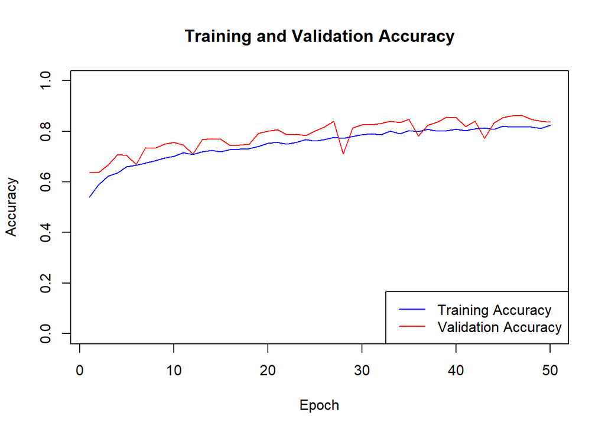

```r
# Plotting Training & Validation Accuracy
plot(history_3$metrics$acc, type = 'l', col = 'blue', ylim = c(0, 1), ylab = 'Accuracy', xlab = 'Epoch', main = 'Training and Validation Accuracy')
lines(history_3$metrics$val_acc, type = 'l', col = 'red')
legend('bottomright', legend = c('Training Accuracy', 'Validation Accuracy'), col = c('blue', 'red'), lty = 1)
```

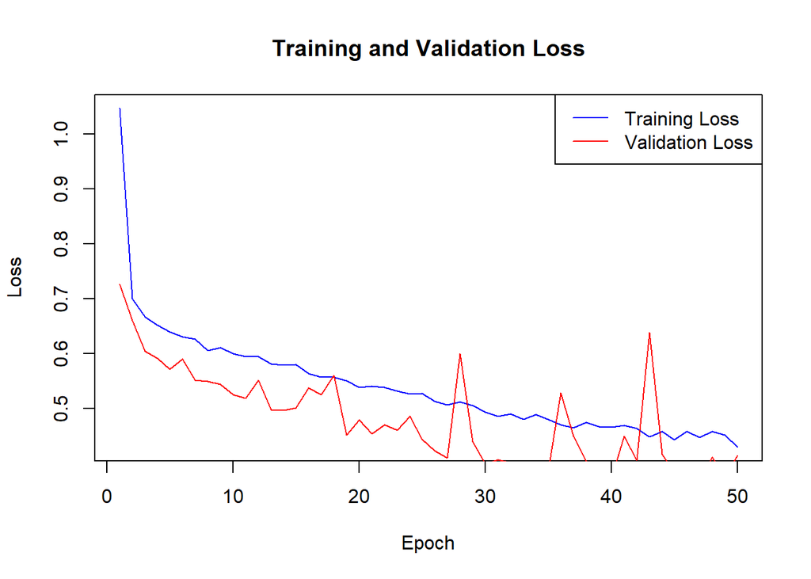

```r
# Plotting Training & Validation Loss
plot(history_3$metrics$loss, type = 'l', col = 'blue', ylab = 'Loss', xlab = 'Epoch', main = 'Training and Validation Loss')
lines(history_3$metrics$val_loss, type = 'l', col = 'red')
legend('topright', legend = c('Training Loss', 'Validation Loss'), col = c('blue', 'red'), lty = 1)
```

From the graphs we can see that using data augmentation with dropout, and increasing the training sample size to 4000 provided an accuracy of about 84% and a loss of 40% at 50 epochs.

4. Using a pre-trained model

```r
# Load the VGG16 model
conv_base <- application_vgg16(
  weights = 'imagenet',
  include_top = FALSE, # Exclude the top (fully connected layers)
  input_shape = c(150, 150, 3)
)
```

```r
extract_features <- function(directory, sample_count) {
  datagen_4 <- image_data_generator(rescale = 1/255)
  generator_4 <- flow_images_from_directory(
    directory = directory,
    generator = datagen_4,
    target_size = c(150, 150),
    batch_size = 20,
    class_mode = 'binary'
  )

  features_4 <- array(0, dim = c(sample_count, 4, 4, 512))
  labels_4 <- array(0, dim = c(sample_count))

  i <- 0
  while(TRUE) {
    batch_4 <- generator_next(generator_4)
    if (is.null(batch_4)) break
    inputs_batch_4 <- batch_4[[1]]
    labels_batch_4 <- batch_4[[2]]
    features_batch_4 <- predict(conv_base, inputs_batch_4)
    num_records_4 <- dim(inputs_batch_4)[1]
    if ((i * 20 + num_records_4) > sample_count) {
        num_records_4 <- sample_count - i * 20
    }
    features_4[(i * 20 + 1):(i * 20 + num_records_4), , , ] <- features_batch_4[1:num_records_4, , , ]
    labels_4[(i * 20 + 1):(i * 20 + num_records_4)] <- labels_batch_4[1:num_records_4]
    i <- i + 1
    if ((i * 20) >= sample_count) break
  }

  return(list(features = features_4, labels = labels_4))
}

# Paths
train_dir_4 <- "C:/Users/reape/OneDrive/Documents/Masters Program/Spring 2024/Advanced Machine Learning/Assignment 2/cats_vs_dogs_small_dataset/cats_vs_dogs_small_dataset/train"
validation_dir_4 <- "C:/Users/reape/OneDrive/Documents/Masters Program/Spring 2024/Advanced Machine Learning/Assignment 2/cats_vs_dogs_small_dataset/cats_vs_dogs_small_dataset/validation"
test_dir_4 <- "C:/Users/reape/OneDrive/Documents/Masters Program/Spring 2024/Advanced Machine Learning/Assignment 2/cats_vs_dogs_small_dataset/cats_vs_dogs_small_dataset/test"

# Extract features and labels for train set
train_results_4 <- extract_features(train_dir_4, 2000)
```

[output not shown]

[output cut: 46 more lines]

[output not shown]

```r
train_features_4 <- train_results_4$features
train_labels_4 <- train_results_4$labels

# Extract features and labels for validation set
validation_results_4 <- extract_features(validation_dir_4, 1000)
```

[output not shown]

```r
validation_features_4 <- validation_results_4$features
validation_labels_4 <- validation_results_4$labels

# Extract features and labels for test set
test_results_4 <- extract_features(test_dir_4, 1000)
```

[output not shown]

```r
test_features_4 <- test_results_4$features
test_labels_4 <- test_results_4$labels

# Flatten the features to feed into a densely connected layer
train_features_4 <- array_reshape(train_features_4, dim = c(dim(train_features_4)[1], 4 * 4 * 512))
validation_features_4 <- array_reshape(validation_features_4, dim = c(dim(validation_features_4)[1], 4 * 4 * 512))
test_features_4 <- array_reshape(test_features_4, dim = c(dim(test_features_4)[1], 4 * 4 * 512))
```

```r
# Define and train the densely connected classifier
model_4 <- keras_model_sequential() %>%
  layer_dense(units = 256, activation = 'relu', input_shape = c(4 * 4 * 512)) %>%
  layer_dropout(rate = 0.5) %>%
  layer_dense(units = 1, activation = 'sigmoid')

model_4 %>% compile(
  optimizer = optimizer_rmsprop(learning_rate = 2e-5),
  loss = 'binary_crossentropy',
  metrics = c('accuracy')
)

history_4 <- model_4 %>% fit(
  x = train_features_4, y = train_labels_4,
  epochs = 30,
  batch_size = 20,
  validation_data = list(validation_features_4, validation_labels_4)
)
```

```
## 100/100 - 1s - loss: 0.6099 - accuracy: 0.6740 - val_loss: 0.4670 - val_accuracy: 0.8140 - 511ms/epoch - 5ms/step
## 100/100 - 0s - loss: 0.4411 - accuracy: 0.8015 - val_loss: 0.3682 - val_accuracy: 0.8710 - 287ms/epoch - 3ms/step
## 100/100 - 0s - loss: 0.3592 - accuracy: 0.8515 - val_loss: 0.3279 - val_accuracy: 0.8760 - 283ms/epoch - 3ms/step
## 100/100 - 0s - loss: 0.3216 - accuracy: 0.8705 - val_loss: 0.2998 - val_accuracy: 0.8850 - 305ms/epoch - 3ms/step
## 100/100 - 0s - loss: 0.2946 - accuracy: 0.8865 - val_loss: 0.2850 - val_accuracy: 0.8920 - 288ms/epoch - 3ms/step
## 100/100 - 0s - loss: 0.2626 - accuracy: 0.8925 - val_loss: 0.2715 - val_accuracy: 0.8970 - 287ms/epoch - 3ms/step
## 100/100 - 0s - loss: 0.2476 - accuracy: 0.8980 - val_loss: 0.2635 - val_accuracy: 0.9000 - 282ms/epoch - 3ms/step
## 100/100 - 0s - loss: 0.2353 - accuracy: 0.9085 - val_loss: 0.2554 - val_accuracy: 0.8990 - 285ms/epoch - 3ms/step
## 100/100 - 0s - loss: 0.2208 - accuracy: 0.9150 - val_loss: 0.2759 - val_accuracy: 0.8790 - 291ms/epoch - 3ms/step
## 100/100 - 0s - loss: 0.2049 - accuracy: 0.9225 - val_loss: 0.2597 - val_accuracy: 0.8910 - 285ms/epoch - 3ms/step
## 100/100 - 0s - loss: 0.1915 - accuracy: 0.9290 - val_loss: 0.2422 - val_accuracy: 0.9040 - 284ms/epoch - 3ms/step
## 100/100 - 0s - loss: 0.1835 - accuracy: 0.9380 - val_loss: 0.2392 - val_accuracy: 0.9080 - 289ms/epoch - 3ms/step
## 100/100 - 0s - loss: 0.1878 - accuracy: 0.9270 - val_loss: 0.2496 - val_accuracy: 0.8920 - 292ms/epoch - 3ms/step
## 100/100 - 0s - loss: 0.1752 - accuracy: 0.9385 - val_loss: 0.2416 - val_accuracy: 0.9080 - 286ms/epoch - 3ms/step
## 100/100 - 0s - loss: 0.1717 - accuracy: 0.9375 - val_loss: 0.2358 - val_accuracy: 0.9030 - 284ms/epoch - 3ms/step
## 100/100 - 0s - loss: 0.1604 - accuracy: 0.9420 - val_loss: 0.2386 - val_accuracy: 0.8990 - 289ms/epoch - 3ms/step
## 100/100 - 0s - loss: 0.1535 - accuracy: 0.9475 - val_loss: 0.2312 - val_accuracy: 0.9090 - 284ms/epoch - 3ms/step
## 100/100 - 0s - loss: 0.1482 - accuracy: 0.9455 - val_loss: 0.2314 - val_accuracy: 0.9090 - 290ms/epoch - 3ms/step
## 100/100 - 0s - loss: 0.1420 - accuracy: 0.9500 - val_loss: 0.2302 - val_accuracy: 0.9090 - 286ms/epoch - 3ms/step
## 100/100 - 0s - loss: 0.1326 - accuracy: 0.9515 - val_loss: 0.2407 - val_accuracy: 0.9030 - 279ms/epoch - 3ms/step
## 100/100 - 0s - loss: 0.1336 - accuracy: 0.9550 - val_loss: 0.2308 - val_accuracy: 0.9100 - 285ms/epoch - 3ms/step
## 100/100 - 0s - loss: 0.1299 - accuracy: 0.9605 - val_loss: 0.2352 - val_accuracy: 0.9080 - 287ms/epoch - 3ms/step
## 100/100 - 0s - loss: 0.1280 - accuracy: 0.9580 - val_loss: 0.2313 - val_accuracy: 0.9070 - 291ms/epoch - 3ms/step
## 100/100 - 0s - loss: 0.1167 - accuracy: 0.9630 - val_loss: 0.2327 - val_accuracy: 0.9060 - 283ms/epoch - 3ms/step
## 100/100 - 0s - loss: 0.1124 - accuracy: 0.9645 - val_loss: 0.2284 - val_accuracy: 0.9050 - 285ms/epoch - 3ms/step
## 100/100 - 0s - loss: 0.1118 - accuracy: 0.9630 - val_loss: 0.2301 - val_accuracy: 0.9070 - 287ms/epoch - 3ms/step
## 100/100 - 0s - loss: 0.1029 - accuracy: 0.9690 - val_loss: 0.2348 - val_accuracy: 0.9070 - 279ms/epoch - 3ms/step
## 100/100 - 0s - loss: 0.1006 - accuracy: 0.9690 - val_loss: 0.2342 - val_accuracy: 0.9050 - 282ms/epoch - 3ms/step
## 100/100 - 0s - loss: 0.0960 - accuracy: 0.9665 - val_loss: 0.2308 - val_accuracy: 0.9060 - 283ms/epoch - 3ms/step
## 100/100 - 0s - loss: 0.0943 - accuracy: 0.9730 - val_loss: 0.2357 - val_accuracy: 0.9050 - 295ms/epoch - 3ms/step
```

```r
#Saving the model
save_model_tf(model_4, "model_4")
```

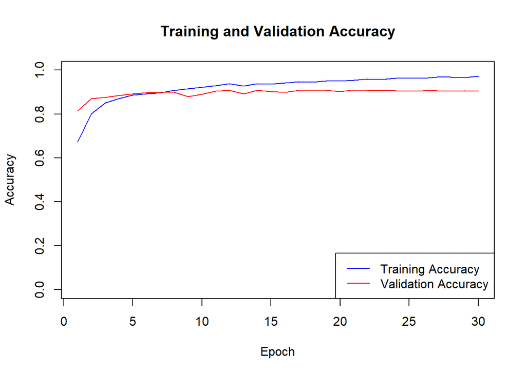

```r
# Plotting Training & Validation Accuracy
plot(history_4$metrics$acc, type = 'l', col = 'blue', ylim = c(0, 1), ylab = 'Accuracy', xlab = 'Epoch', main = 'Training and Validation Accuracy')
lines(history_4$metrics$val_acc, type = 'l', col = 'red')
legend('bottomright', legend = c('Training Accuracy', 'Validation Accuracy'), col = c('blue', 'red'), lty = 1)
```

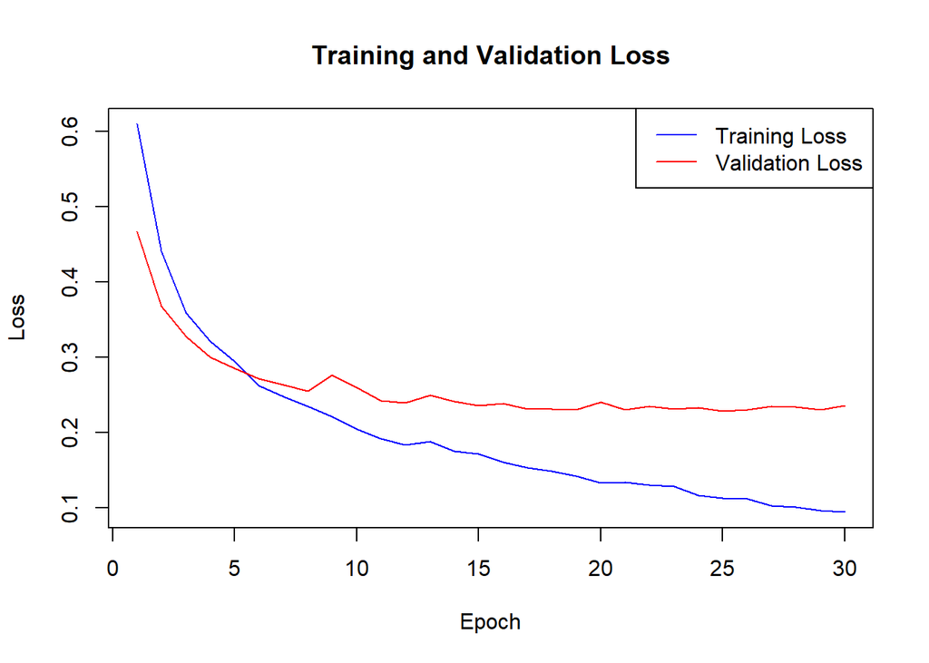

```r
# Plotting Training & Validation Loss
plot(history_4$metrics$loss, type = 'l', col = 'blue', ylab = 'Loss', xlab = 'Epoch', main = 'Training and Validation Loss')
lines(history_4$metrics$val_loss, type = 'l', col = 'red')
legend('topright', legend = c('Training Loss', 'Validation Loss'), col = c('blue', 'red'), lty = 1)
```

From the graphs we can see that using VGG16 mode with dropout on our original model_1 data produced significantly different results. We can see that this model is overfitting very early on. This is because this method can not utilize data augmentation. This model produced performance of about 97% accuracy and about 9% loss.

```r
# Define directories using model_2's data
train_dir_5 <- "C:/Users/reape/OneDrive/Documents/Masters Program/Spring 2024/Advanced Machine Learning/Assignment 2/kagglecatsanddogs_5340/PetImages/train_2"
validation_dir_5 <- "C:/Users/reape/OneDrive/Documents/Masters Program/Spring 2024/Advanced Machine Learning/Assignment 2/kagglecatsanddogs_5340/PetImages/validation_2"
test_dir_5 <- "C:/Users/reape/OneDrive/Documents/Masters Program/Spring 2024/Advanced Machine Learning/Assignment 2/kagglecatsanddogs_5340/PetImages/test_2"


train_datagen_5 <- image_data_generator(
  rescale = 1/255,
  rotation_range = 20,
  width_shift_range = 0.1,
  height_shift_range = 0.1,
  shear_range = 0.1,
  zoom_range = 0.1,
  horizontal_flip = TRUE,
  fill_mode = 'nearest'
)

test_datagen_5 <- image_data_generator(rescale = 1/255)

train_generator_5 <- flow_images_from_directory(
  train_dir_5,
  train_datagen_5,
  target_size = c(150, 150),
  batch_size = 30,
  class_mode = 'binary'
)
```

```
## Found 3000 images belonging to 2 classes.
```

```r
validation_generator_5 <- flow_images_from_directory(
  validation_dir_5,
  test_datagen_5,
  target_size = c(150, 150),
  batch_size = 30,
  class_mode = 'binary'
)
```

```
## Found 1000 images belonging to 2 classes.
```

```r
conv_base <- application_mobilenet_v2(weights = 'imagenet', include_top = FALSE, input_shape = c(128, 128, 3))

# Set the entire model to be trainable
conv_base$trainable <- TRUE

# Freeze all layers except for the last convolutional block
for (layer in conv_base$layers) {
  # Check if the layer is a convolutional layer
  if (grepl("conv", layer$name)) {
    # Unfreeze the last convolutional block
    layer$trainable <- grepl("block5", layer$name)
  } else {
    # Freeze non-convolutional layers
    layer$trainable <- FALSE
  }
}
```

```r
# Define model_5

batch_size_5 = 32

model_5 <- keras_model_sequential() %>%
  conv_base %>%
  layer_flatten() %>%
  layer_dense(units = 128, activation = 'relu') %>%
  layer_dropout(0.5) %>%
  layer_dense(units = 1, activation = 'sigmoid')

# Use Adam optimizer for potentially faster convergence
model_5 %>% compile(
  loss = 'binary_crossentropy',
  optimizer = optimizer_adam(learning_rate = 1e-4),
  metrics = c('accuracy')
)

# Implement early stopping
early_stopping <- callback_early_stopping(monitor = "val_loss", patience = 5)
```

```r
# Train the model
history_5 <- model_5 %>% fit(
  train_generator_5,
  steps_per_epoch = as.integer(3000 / batch_size_5),
  epochs = 20,  # Reduced the number of epochs
  validation_data = validation_generator_5,
  validation_steps = as.integer(1000 / batch_size_5),
  callbacks = list(early_stopping)  # Added callback
)
```

```
## 93/93 - 10s - loss: 0.2150 - accuracy: 0.9143 - val_loss: 0.0751 - val_accuracy: 0.9720 - 10s/epoch - 109ms/step
## 93/93 - 9s - loss: 0.1212 - accuracy: 0.9505 - val_loss: 0.0699 - val_accuracy: 0.9742 - 9s/epoch - 93ms/step
## 93/93 - 9s - loss: 0.1144 - accuracy: 0.9552 - val_loss: 0.0649 - val_accuracy: 0.9742 - 9s/epoch - 93ms/step
## 93/93 - 9s - loss: 0.0920 - accuracy: 0.9645 - val_loss: 0.0804 - val_accuracy: 0.9710 - 9s/epoch - 93ms/step
## 93/93 - 9s - loss: 0.0840 - accuracy: 0.9667 - val_loss: 0.0676 - val_accuracy: 0.9742 - 9s/epoch - 93ms/step
## 93/93 - 9s - loss: 0.0762 - accuracy: 0.9717 - val_loss: 0.0599 - val_accuracy: 0.9753 - 9s/epoch - 93ms/step
## 93/93 - 9s - loss: 0.0646 - accuracy: 0.9756 - val_loss: 0.0671 - val_accuracy: 0.9828 - 9s/epoch - 92ms/step
## 93/93 - 9s - loss: 0.0689 - accuracy: 0.9763 - val_loss: 0.0667 - val_accuracy: 0.9774 - 9s/epoch - 93ms/step
## 93/93 - 9s - loss: 0.0580 - accuracy: 0.9781 - val_loss: 0.0755 - val_accuracy: 0.9710 - 9s/epoch - 92ms/step
## 93/93 - 9s - loss: 0.0490 - accuracy: 0.9785 - val_loss: 0.0703 - val_accuracy: 0.9753 - 9s/epoch - 93ms/step
## 93/93 - 9s - loss: 0.0568 - accuracy: 0.9753 - val_loss: 0.0735 - val_accuracy: 0.9753 - 9s/epoch - 92ms/step
```

```r
#Saving the model
save_model_tf(model_5, "model_5")
```

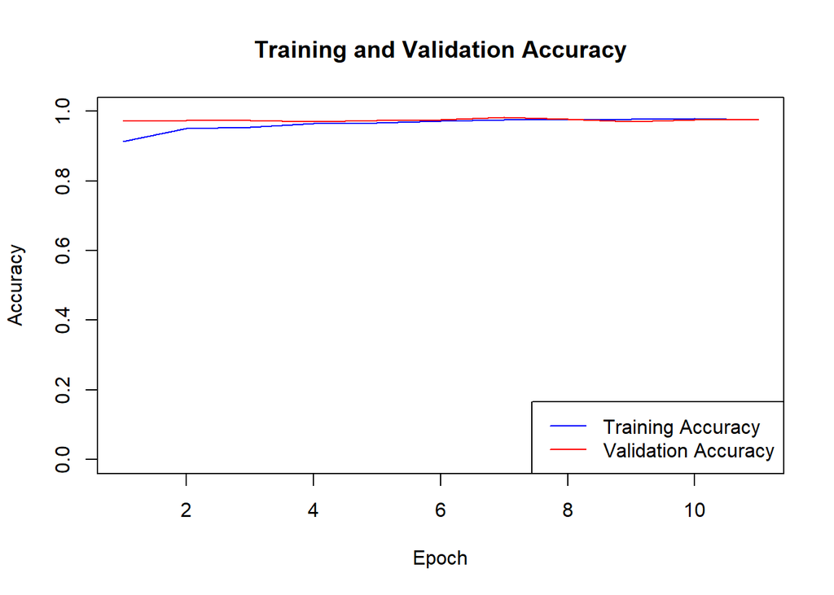

```r
# Plotting Training & Validation Accuracy
plot(history_5$metrics$acc, type = 'l', col = 'blue', ylim = c(0, 1), ylab = 'Accuracy', xlab = 'Epoch', main = 'Training and Validation Accuracy')
lines(history_5$metrics$val_acc, type = 'l', col = 'red')
legend('bottomright', legend = c('Training Accuracy', 'Validation Accuracy'), col = c('blue', 'red'), lty = 1)
```

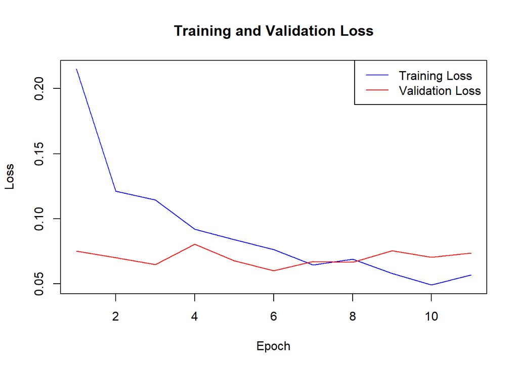

```r
# Plotting Training & Validation Loss
plot(history_5$metrics$loss, type = 'l', col = 'blue', ylab = 'Loss', xlab = 'Epoch', main = 'Training and Validation Loss')
lines(history_5$metrics$val_loss, type = 'l', col = 'red')
legend('topright', legend = c('Training Loss', 'Validation Loss'), col = c('blue', 'red'), lty = 1)
```

Using the mobilenet_v2 model, with feature extraction, and implementing an early stop shows a performance of about 97% accuracy at epoch 9, as well as a loss of about 6%.

```r
# Directories for model_3's training, validation, and test data
train_dir_6 <- 'C:/Users/reape/OneDrive/Documents/Masters Program/Spring 2024/Advanced Machine Learning/Assignment 2/kagglecatsanddogs_5340/PetImages/train_3'
validation_dir_6 <- 'C:/Users/reape/OneDrive/Documents/Masters Program/Spring 2024/Advanced Machine Learning/Assignment 2/kagglecatsanddogs_5340/PetImages/validation_3'
test_dir_6 <- 'C:/Users/reape/OneDrive/Documents/Masters Program/Spring 2024/Advanced Machine Learning/Assignment 2/kagglecatsanddogs_5340/PetImages/test_3'


train_datagen_6 <- image_data_generator(
  rescale = 1/255,
  rotation_range = 20,
  width_shift_range = 0.1,
  height_shift_range = 0.1,
  shear_range = 0.1,
  zoom_range = 0.1,
  horizontal_flip = TRUE,
  fill_mode = 'nearest'
)

test_datagen_6 <- image_data_generator(rescale = 1/255)

train_generator_6 <- flow_images_from_directory(
  train_dir_6,
  train_datagen_6,
  target_size = c(128, 128),
  batch_size = 32,
  class_mode = 'binary'
)
```

```
## Found 4000 images belonging to 2 classes.
```

```r
validation_generator_6 <- flow_images_from_directory(
  validation_dir_6,
  test_datagen_6,
  target_size = c(128, 128),
  batch_size = 32,
  class_mode = 'binary'
)
```

```
## Found 1000 images belonging to 2 classes.
```

```r
# MobileNetV2 model setup
conv_base <- application_mobilenet_v2(weights = 'imagenet', include_top = FALSE, input_shape = c(128, 128, 3))

# Set the entire model to be trainable
conv_base$trainable <- TRUE

# Freeze all layers except for the last convolutional block
for (layer in conv_base$layers) {
  if (grepl("conv", layer$name)) {
    layer$trainable <- grepl("block16", layer$name)  # Adjusted to MobileNetV2's last block
  } else {
    layer$trainable <- FALSE
  }
}
```

```r
# Define model_6 with the MobileNetV2 base
model_6 <- keras_model_sequential() %>%
  conv_base %>%
  layer_flatten() %>%
  layer_dense(units = 128, activation = 'relu') %>%
  layer_dropout(0.5) %>%
  layer_dense(units = 1, activation = 'sigmoid')

# Compile model_6
model_6 %>% compile(
  loss = 'binary_crossentropy',
  optimizer = optimizer_adam(learning_rate = 1e-4),
  metrics = c('accuracy')
)

# Implement early stopping
early_stopping <- callback_early_stopping(monitor = "val_loss", patience = 5)
```

```r
# Train the model
history_6 <- model_6 %>% fit(
  train_generator_6,
  steps_per_epoch = as.integer(3000 / 32),
  epochs = 20,  # Reduced the number of epochs for faster training
  validation_data = validation_generator_6,
  validation_steps = as.integer(1000 / 32),
  callbacks = list(early_stopping)
)
```

```
## 93/93 - 9s - loss: 0.2333 - accuracy: 0.9073 - val_loss: 0.0876 - val_accuracy: 0.9647 - 9s/epoch - 97ms/step
## 93/93 - 8s - loss: 0.1405 - accuracy: 0.9439 - val_loss: 0.0733 - val_accuracy: 0.9758 - 8s/epoch - 81ms/step
## 93/93 - 8s - loss: 0.1214 - accuracy: 0.9540 - val_loss: 0.0839 - val_accuracy: 0.9667 - 8s/epoch - 81ms/step
## 93/93 - 7s - loss: 0.1120 - accuracy: 0.9543 - val_loss: 0.1015 - val_accuracy: 0.9627 - 7s/epoch - 81ms/step
## 93/93 - 7s - loss: 0.1004 - accuracy: 0.9587 - val_loss: 0.0783 - val_accuracy: 0.9667 - 7s/epoch - 81ms/step
## 93/93 - 7s - loss: 0.1063 - accuracy: 0.9583 - val_loss: 0.0809 - val_accuracy: 0.9677 - 7s/epoch - 80ms/step
## 93/93 - 7s - loss: 0.0898 - accuracy: 0.9657 - val_loss: 0.1050 - val_accuracy: 0.9607 - 7s/epoch - 80ms/step
```

```r
# Save the model
save_model_tf(model_6, "model_6")
```

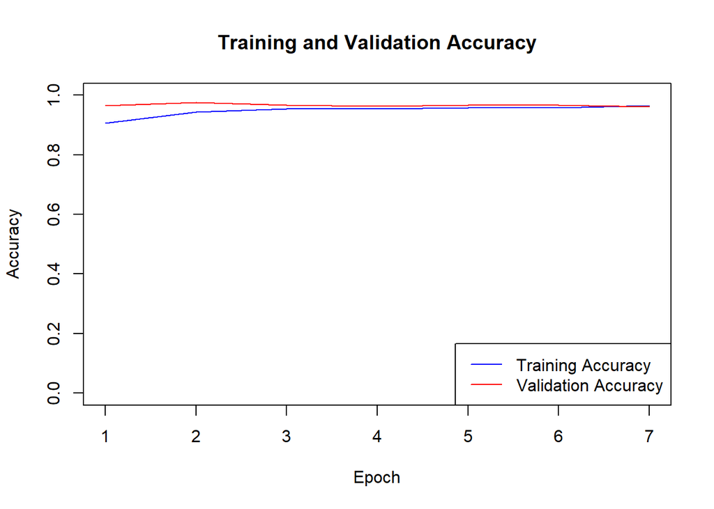

```r
min_loss <- min(c(history_6$metrics$loss, history_6$metrics$val_loss))
max_loss <- max(c(history_6$metrics$loss, history_6$metrics$val_loss))

# Plotting Training & Validation Accuracy
plot(history_6$metrics$acc, type = 'l', col = 'blue', ylim = c(0, 1), ylab = 'Accuracy', xlab = 'Epoch', main = 'Training and Validation Accuracy')
lines(history_6$metrics$val_acc, type = 'l', col = 'red')
legend('bottomright', legend = c('Training Accuracy', 'Validation Accuracy'), col = c('blue', 'red'), lty = 1)
```

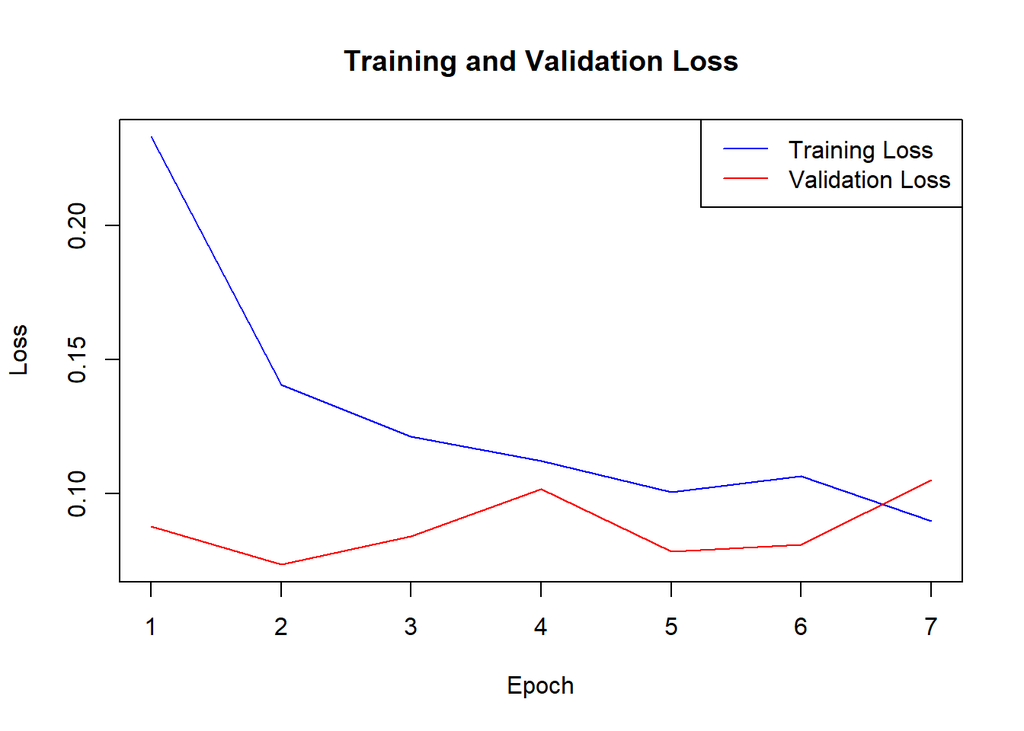

```r
# Plotting Training & Validation Loss with adjusted ylim
plot(history_6$metrics$loss, type = 'l', col = 'blue', ylim = c(min_loss, max_loss), ylab = 'Loss', xlab = 'Epoch', main = 'Training and Validation Loss')
lines(history_6$metrics$val_loss, type = 'l', col = 'red')
legend('topright', legend = c('Training Loss', 'Validation Loss'), col = c('blue', 'red'), lty = 1)
```